# Homework 5

Quinn Dellinger

10/31/2019

library(tidyverse) library(doParallel) library(foreach)

## HW 5 Problems

Below you will find problems for you to complete as an individual. It is fine to discuss the homework problems with classmates, but cheating is prohibited and will be harshly penalized if detected.

### 1. Using the **ggplot** function and tidyverse functionality, do the following visualizations:

1. recreate your improved visualization in **problem 2c of HW04**

```r
library(tidyverse)
```

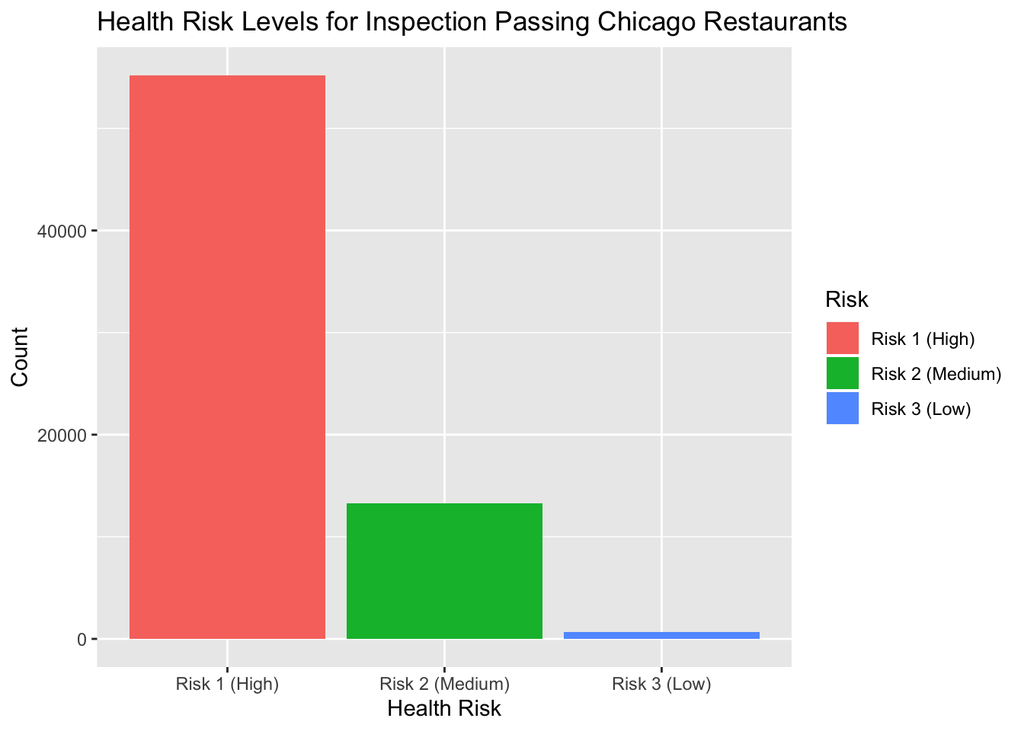

```r
food_data<-read.csv("Food_Inspections.csv")
restaurant<-food_data[which(food_data$Facility.Type == "Restaurant"),]
passing_restaurants <- restaurant[restaurant$Results == "Pass",]
ggplot(data = passing_restaurants) +
  geom_bar(mapping = aes(x = Risk, fill = Risk)) +
  labs(title = "Health Risk Levels for Inspection Passing Chicago Restaurants") +
  ylab("Count") +
  xlab("Health Risk")
```

2. add a new visually appealing layer to the plot that helps clarify the plot and separately include a short description beneath the plot, such as “Fig. 1 shows…”

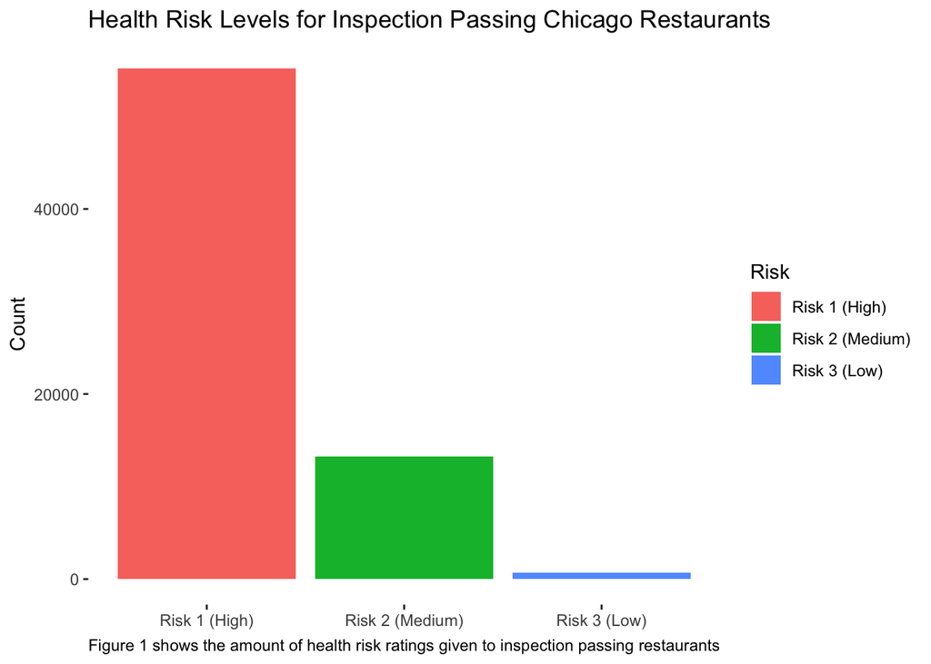

```r
library(tidyverse)
ggplot(data = passing_restaurants) +
  geom_bar(mapping = aes(x = Risk, fill = Risk)) +
  labs(title = "Health Risk Levels for Inspection Passing Chicago Restaurants", caption = "Figure 1 shows the amount of health risk ratings given to inspection passing restaurants") +
  ylab("Count") +
  theme(panel.grid.major = element_blank(), panel.grid.minor = element_blank(),
        panel.background = element_blank(),axis.title.x=element_blank())
```

3. recreate your improved visualization in **problem 4c of HW04**

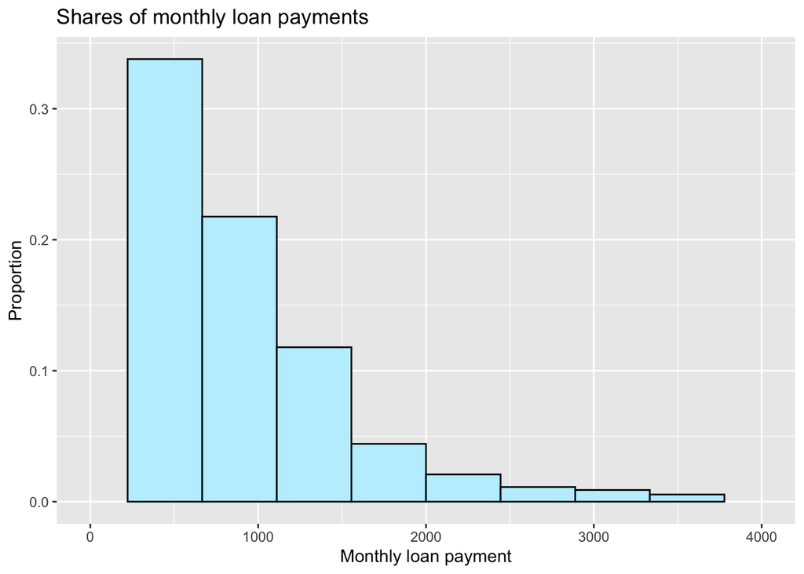

```r
library(tidyverse)
loan_data<-read.csv("SBAnational.csv")
loan_length<-loan_data$Term
loan_amount<-as.numeric(loan_data$DisbursementGross)
amount_to_term <- loan_amount/loan_length
years<-loan_data$ApprovalFY
years<-as.numeric(years)
data <- as.data.frame(cbind(years,amount_to_term))
ggplot(data,aes(x=amount_to_term)) +
  geom_histogram(aes(y = ..count../sum(..count..)), fill = "lightblue1", bins = 10, color = "black") +
  xlim(0,4000) +
  ylab("Proportion") +
  xlab("Monthly loan payment") +
  labs(title = "Shares of monthly loan payments")
```

4. add a new visually appealing layer to the plot that helps clarify the plot and separately include a short description beneath the plot, such as “Fig. 2 shows…”

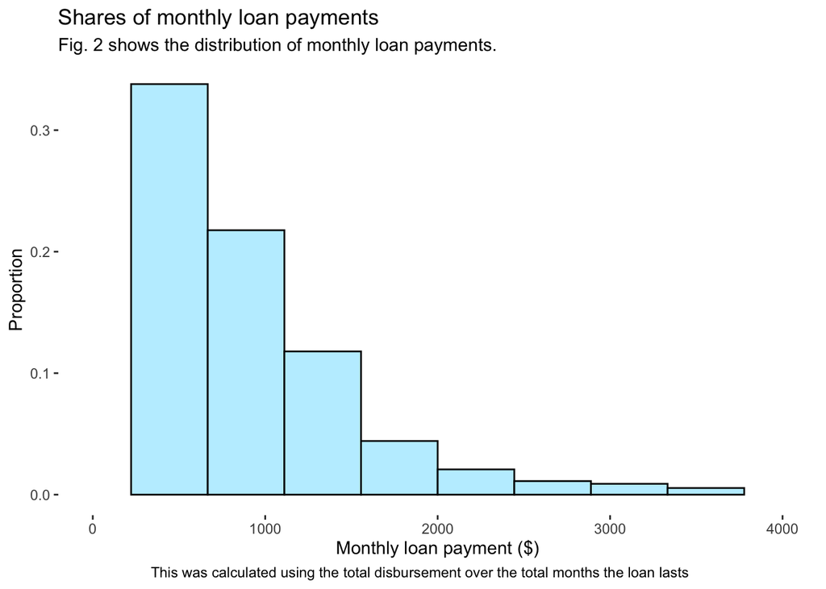

```r
library(tidyverse)
ggplot(data,aes(x=amount_to_term)) +
  geom_histogram(aes(y = ..count../sum(..count..)), fill = "lightblue1", bins = 10, color = "black") +
  xlim(0,4000) +
  ylab("Proportion") +
  xlab("Monthly loan payment ($)") +
  labs(title = "Shares of monthly loan payments", subtitle = "Fig. 2 shows the distribution of monthly loan payments.", caption = "This was calculated using the total disbursement over the total months the loan lasts                                ") +
  theme(panel.grid.major = element_blank(), panel.grid.minor = element_blank(),
        panel.background = element_blank())
```

### 2. Successfully import the US Natality Data (for year 2015). The necessary data links are in the Datasets file on Prof. Kinson’s course website. One is a single csv file 1.9 GB in size. If your computer cannot handle that processing, do use the partitioned version of the data, which are 20 csv files of the same US Natality Data.

#### **Bonus (worth 5 additional points, i.e. your max HW 05 score could be 15 out of 10): do problem 2 using parallel programming ideas (particularly with foreach) discussed in class. No outside functions/packages other than those discussed in the notes on parallel programming.**

```r
natality_data <- read.csv(url("https://uofi.box.com/shared/static/4133zicq6vjuceoy00nmotaqynbg7d4t.csv"))

#I tried putting the 20 partitioned files together
#but the code below gives the error of reaching the vector memory limit
# library(doParallel)
# library(foreach)
# c1 <- makeCluster(1)
# registerDoParallel(c1)
# #This code makes a list of lists (of lists) with each spreadsheet as an element
# temp <- foreach (i = 1:20) %dopar% {
#   data <- read.csv(paste("/Users/quinndellinger/Documents/School/Stats/GitHub/qpd2/Homework 5/natality_data/",i,".csv",sep=""))
# }
# #When I try to turn it into something I can work with in ggplot, I run out of memory
# natality_data <- apply(matrix(temp),1,unlist)
# stopCluster(c1)
```

### 3. Using the **ggplot** function and tidyverse functionality, recreate or reimagine the following visualizations using the appropriate data. Be sure to use the visual design considerations from Knaflic’s **Storytelling with Data**.

1. The image below uses the US Natality Data. Also, explain the image with Markdown syntax.

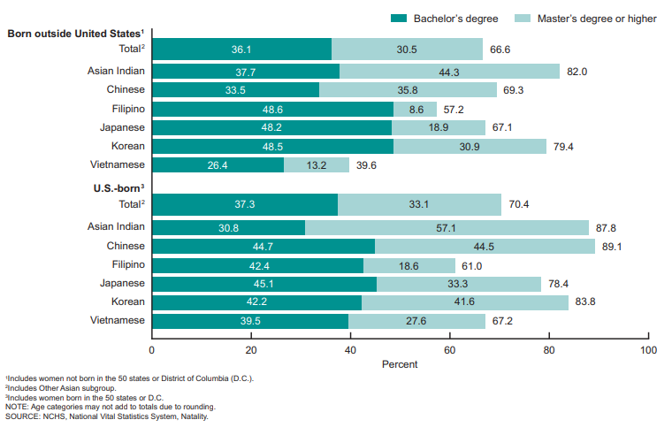

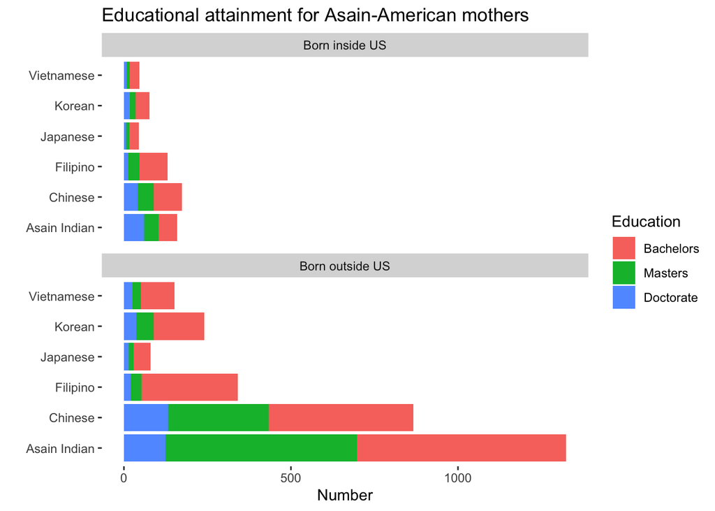

```r
#MBSTATE_REC - 1 is born inside, 2 is born outside
#MRACE15
#MEDUC 6 is bachelor - 7 & 8 above is more
library(tidyverse)
asains <- filter(natality_data, MRACE15 == c(4,5,6,7,8,9))
educated <- filter(asains, MEDUC == c(6,7,8))
educated <- filter(educated, MBSTATE_REC == c(1,2))
educated$MBSTATE_REC <- factor(educated$MBSTATE_REC, labels = c("Born inside US","Born outside US"))
educated$MEDUC <- as.character(educated$MEDUC)
educated$MRACE15 <- factor(educated$MRACE15, labels = c("Asain Indian","Chinese","Filipino","Japanese","Korean","Vietnamese"))

# 04 Asian Indian (only)
# 05 Chinese (only)
# 06 Filipino (only)
# 07 Japanese (only)
# 08 Korean (only)
# 09 Vietnamese (only)

ggplot(data = educated) +
  geom_bar(mapping = aes(x = MRACE15, fill = MEDUC)) +
  scale_fill_discrete(name = c("Education"),labels = c("Bachelors","Masters","Doctorate")) +
  coord_flip() +
  theme(panel.grid.major = element_blank(), panel.grid.minor = element_blank(),
        panel.background = element_blank()) +
  xlab("") +
  ylab("Number") +
  facet_wrap(~factor(MBSTATE_REC), nrow = 2, ncol = 1) +
  ggtitle("Educational attainment for Asain-American mothers")
```

The graphs shows that a far greater number of Asain-American mothers were born outside the US, with most of them being Chinese or Indian. It is intersting to note that more than a third of the Indian mothers born inside the US that went to college, went beyond and got doctorate degree.

2. The image below uses the US Natality Data. Also, explain the image with Markdown syntax (do not include the explanation within the visualization).


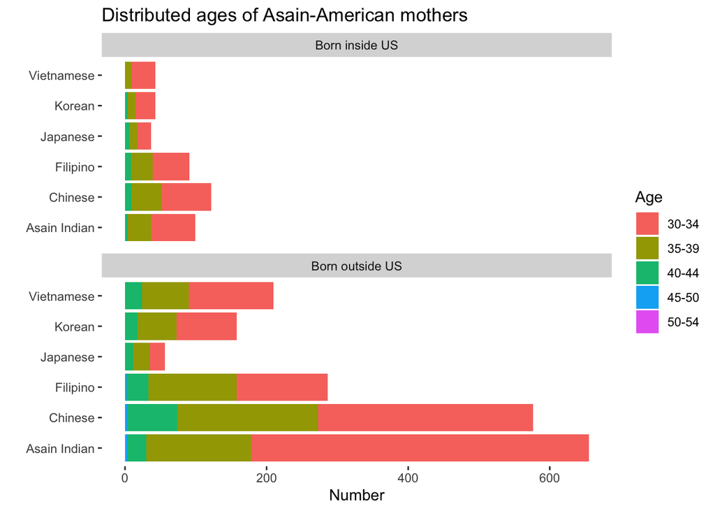

```r
#MAGER9 - 5-9
old <- filter(asains, MAGER9 == c(5,6,7,8,9))
old <- filter(old, MBSTATE_REC == c(1,2))
old$MBSTATE_REC <- factor(old$MBSTATE_REC, labels = c("Born inside US","Born outside US"))
old$MAGER9 <- factor(old$MAGER9, labels = c("30-34","35-39","40-44","45-50","50-54"))
old$MRACE15 <- factor(old$MRACE15, labels = c("Asain Indian","Chinese","Filipino","Japanese","Korean","Vietnamese"))
ggplot(data = old) +
  geom_bar(mapping = aes(x = MRACE15, fill = MAGER9)) +
  scale_fill_discrete(name = c("Age"),labels = c("30-34","35-39","40-44","45-50","50-54")) +
  coord_flip() +
  theme(panel.grid.major = element_blank(), panel.grid.minor = element_blank(),
        panel.background = element_blank()) +
  xlab("") +
  ylab("Number") +
  facet_wrap(~factor(MBSTATE_REC), nrow = 2, ncol = 1) +
  ggtitle("Distributed ages of Asain-American mothers")
```

3. The image below uses the Chicago Food Inspections Data [link here](https://uofi.box.com/shared/static/5637axblfhajotail80yw7j2s4r27hxd.csv). Also, explain the image with Markdown syntax (do not include the explanation within the visualization).

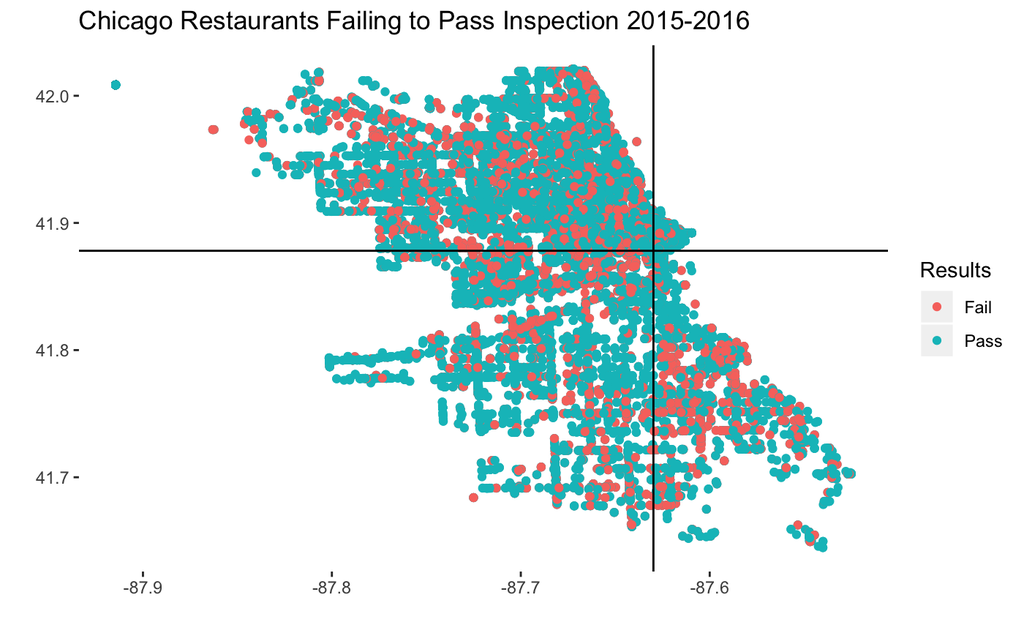

```r
library(tidyverse)
pass_fail <- filter(food_data, Results == "Pass" | Results == "Fail")
pass_fail$Inspection.Date <- as.Date(pass_fail$Inspection.Date, format = '%Y-%m-%d')
pass_fail <- filter(pass_fail, Inspection.Date >= "2015-01-01")
pass_fail <- filter(pass_fail, Inspection.Date <= "2017-01-01")
plot1 <- ggplot(data = pass_fail) +
  geom_point(mapping = aes(y = Latitude, x = Longitude, color = Results)) +
  geom_vline(xintercept=-87.6298) +
  geom_hline(yintercept=41.8781) +
  xlab("") +
  ylab("") +
  labs(title = "Chicago Restaurants Failing to Pass Inspection 2015-2016") +
  theme(panel.grid.major = element_blank(), panel.grid.minor = element_blank(),
        panel.background = element_blank())
```

4. The image below uses the Chicago Food Inspections Data. Also, explain the image with Markdown syntax (do not include the explanation within the visualization).

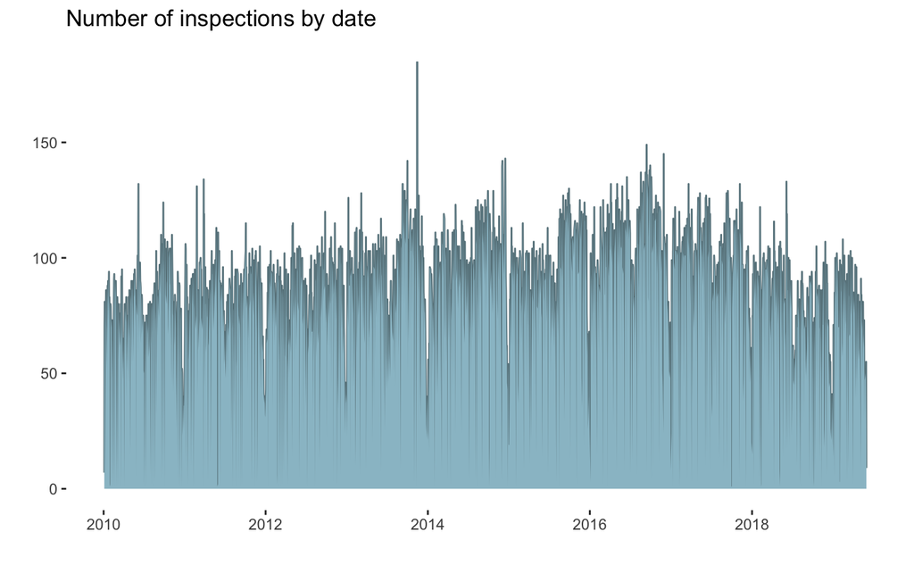

```r
library(tidyverse)
df <- as.data.frame(table(food_data$Inspection.Date))
df$Var1 <- as.Date(df$Var1)

plot2 <- ggplot(data = df, aes(x = Var1, y = Freq)) +
  geom_line(color = "lightblue4") +
  geom_area(fill = "lightblue3") +
  ylab("") +
  xlab("") +
  labs(title = "Number of inspections by date") +
  theme(panel.grid.major = element_blank(), panel.grid.minor = element_blank(),
        panel.background = element_blank())
```

### 4. Do the following:

Redo problem 3 in HW03 using the parallel programming. Does parallel computing perform the tasks in parts c and e faster than the method that you used in HW03? Show your work including the runtimes for the un-parallelized and parallelized versions.

```r
library(doParallel)
```

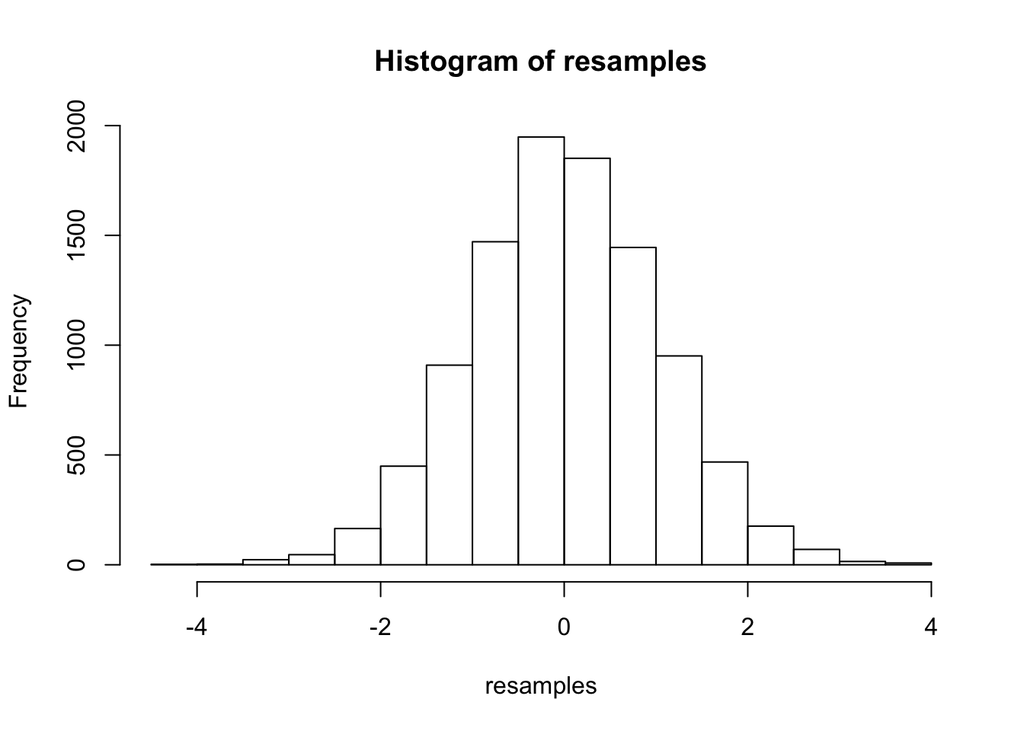

```r
time1 <- system.time({
c1 <- makeCluster(2)
registerDoParallel(c1)

data<-read.csv("dataHW3.csv")

x<-data[,1]
stat<-(mean(x)-10)/(sd(x)/sqrt(length(x)))
stat

mean_x<-mean(x)
prime_matrix<-matrix(data = NA,nrow = 50, ncol = 10000)

para <- foreach (i = 1:ncol(prime_matrix)) %dopar% {
x_prime<-as.vector(sample(x,50,replace=TRUE))
prime_matrix[,i]<-x_prime
}


run_stat<-function(v2){
stat<-(mean(v2)-mean_x)/(sd(v2)/sqrt(length(v2)))
}

prime_matrix <- apply(matrix(para),1,unlist)
resamples<-apply(prime_matrix,2,run_stat)

hist(resamples, breaks = 20)
})
```

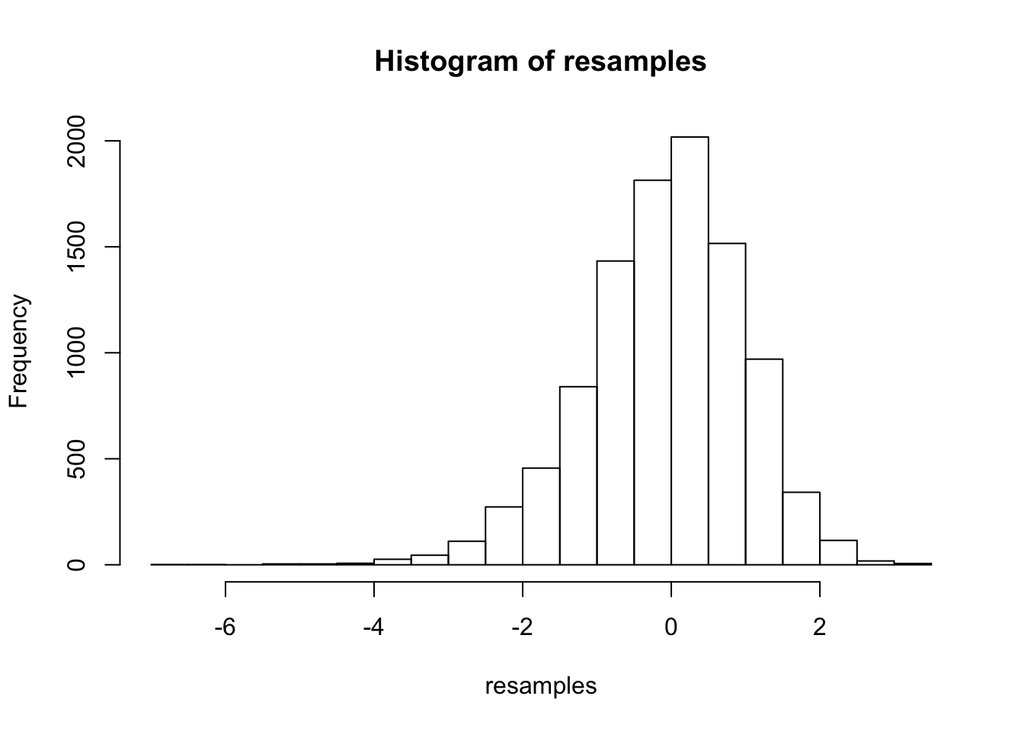

```r
stopCluster(c1)

time2 <- system.time({
x<-data[,2]
stat<-(mean(x)-10)/(sd(x)/sqrt(length(x)))
stat
mean_x<-mean(x)

prime_matrix<-matrix(data = NA, nrow = 50, ncol = 10000)

for(i in 1:ncol(prime_matrix)) {
x_prime<-sample(x,length(x),replace=TRUE)
prime_matrix[,i]<-x_prime
}

resamples<-apply(prime_matrix,2,run_stat)

hist(resamples,breaks = 20)
})
```

```r
time1<-time1[3]
time2<-time2[3]
paste("In parallel, the calculation took",time1,"seconds. Regularly, it took",time2,"seconds")
```

```
## [1] "In parallel, the calculation took 4.05600000000004 seconds. Regularly, it took 0.226999999999975 seconds"
```

### 5. Problem in parallel coding

install.packages(“tidyverse”)

1. Install the **conformal.glm** R package which can be found at https://github.com/DEck13/conformal.glm.  
   Run the following code:

```r
library(devtools)
install_github(repo = "DEck13/conformal.glm", subdir="conformal.glm")
```

```
## Skipping install of 'conformal.glm' from a github remote, the SHA1 (9d362f17) has not changed since last install.
##   Use `force = TRUE` to force installation
```

```r
library(conformal.glm)
set.seed(13)
n <- 250

# generate predictors
x <- runif(n)

# set regression coefficient vector
beta <- c(3, 5)

# generate responses from a linear regression model
y <- rnorm(n, mean = cbind(1, x) %*% beta, sd = 3)

# store predictors and responses as a dataframe
dat <- data.frame(y = y, x = x)

# fit linear regression model
model <- lm(y ~ x, data = dat)

# obtain OLS estimator of beta
betahat <- model$coefficients

# convert predictors into a matrix
Xk <- as.matrix(x, nrow = n)

# extract internal model information, this is necessary for the assignment
call <- model$call
formula <- call$formula
family <- "gaussian"
link <- "identity"
newdata.formula <- as.matrix(model.frame(formula, as.data.frame(dat))[, -1])

# This function takes on a new (x,y) data point and reports a
# value corresponding to how similar this new data point is
# with the data that we generated, higher numbers are better.
# The goal is to use this function to get a range of new y
# values that agrees with our generated data at each x value in
# our generated data set.
density_score <- function(ynew, xnew){
  rank(phatxy(ynew = ynew, xnew = xnew, Yk = y, Xk = Xk, xnew.modmat = xnew,
    data = dat, formula = formula, family = family, link = link))[n+1]
}

# We try this out on the first x value in our generated data set.
# In order to do this we write two line searches
xnew <- x[1]

# start line searches at the predicted response value
# corresponding to xnew
ystart <- ylwr <- yupr <- as.numeric(c(1,xnew) %*% betahat)
score <- density_score(ynew = ystart, xnew = xnew)

# line search 1: line search that estimates the largest y
# value corresponding to the first x value that agrees with
# our generated data
while(score > 13){
  yupr <- yupr + 0.01
  score <- density_score(ynew = yupr, xnew = xnew)
}

# line search 2: line search that estimates the smallest y
# value corresponding to the first x value that agrees with
# our generated data
score <- density_score(ynew = ystart, xnew = xnew)
while(score > 13){
  ylwr <- ylwr - 0.01
  score <- density_score(ynew = ylwr, xnew = xnew)
}
```

2. Write a function which runs the two line searches in part **a** for the jth generated predictor value.

```r
library(conformal.glm)
line_search <- function(jth) {
  xnew <- x[jth]
  ystart <- ylwr <- yupr <- as.numeric(c(1,xnew) %*% betahat)
  score <- density_score(ynew = ystart, xnew = xnew)
  while(score > 13){
    yupr <- yupr + 0.01
    score <- density_score(ynew = yupr, xnew = xnew)
  }
  score <- density_score(ynew = ystart, xnew = xnew)
  while(score > 13){
    ylwr <- ylwr - 0.01
    score <- density_score(ynew = ylwr, xnew = xnew)
  }
  finish <- c(ylwr,yupr)
  return(finish)
}
```

3. Use parallel programming to run the function you wrote in part **b**. Save the output and record the time that it took to perform these calculations *NOTE: It is not advised to use `detectCores` as an argument in defining the number of workers you want. It’s much better to specify the number of workers explicitly.*

```r
library(doParallel)
library(conformal.glm)
time1 <- system.time({
c1 <- makeCluster(2)
registerDoParallel(c1)
help <- foreach(i = 1:250) %dopar% {
  library(conformal.glm)
  line_search(i)
}
})
stopCluster(c1)
time1 <- time1[3]
```

4. Redo the calculation in part **c** using `lapply` and record the time it took to run this job. Which method is faster?

```r
time2 <- system.time({
ok <- lapply(1:250,line_search)
})
time2 <- time2[3]
time3 <- time2 - time1
paste("Doing the calculation in parallel is faster by",time3,"seconds")
```

```
## [1] "Doing the calculation in parallel is faster by 214.802 seconds"
```

5. Using **ggplot**, plot the original data and depict lines of the lower and upper boundaries that you computed from part **c**.

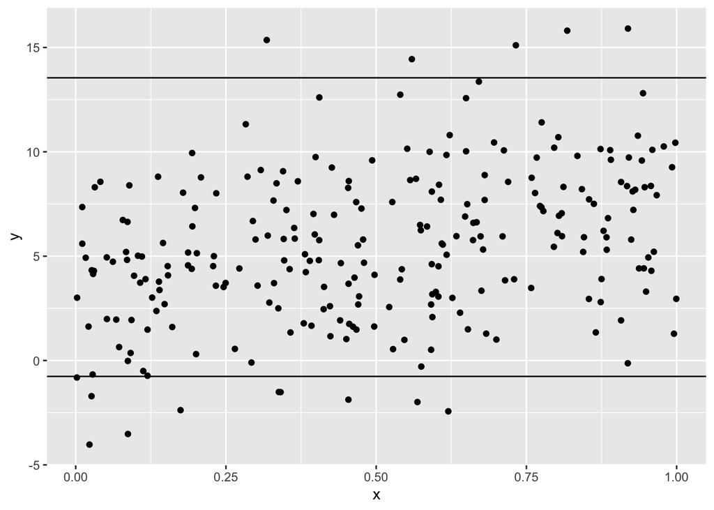

```r
library(tidyverse)
x<-as.data.frame(x)
ok <- apply(matrix(ok),1,unlist)
ggplot(data = dat) +
  geom_point(aes(x = x, y = y)) +
  geom_hline(yintercept = ok[1]) +
  geom_hline(yintercept = ok[2])
```